# Structured Data Analysis with Spark

## 2. Data Analysis

```python
movie_details = sqlContext.read.json("hdfs:///aula_B0.485/data/movie_details.json")
```

```python
reviews = sqlContext.read.json("hdfs:///aula_B0.485/data/reviews.json")
```

### 2.1 Queries Using SQL

Spark allows us to perform SQL queries on DataFrames, which we first need to register as tables. Therefore, we will register the `movie_details` DataFrame as a table and perform some basic queries.

```python
movie_details.registerTempTable("movie_details_table")
```

The way to access this database is by creating a Hive context, similar to how we declare an SQL context. First, we declare a variable `hiveContext` by instantiating it as an object of the `HiveContext` class. Then, we check how many tables are registered in this context. As we can see, the table we just stored is temporarily registered, while we have other tables registered permanently.

```python
hiveContext = HiveContext(sc)
hiveContext.tables().show()
hiveContext.sql("DESCRIBE movie_details_table").show()
```

```
+--------+-------------------+-----------+
|database|          tableName|isTemporary|
+--------+-------------------+-----------+
| default|                 as|      false|
| default|          mistweets|      false|
| default|       province_28a|      false|
| default|  province_28a_vext|      false|
| default|                src|      false|
| default|          tweets28a|      false|
| default|     tweets28a_vext|      false|
| default|          user_info|      false|
| default|     user_info_vext|      false|
|        |movie_details_table|       true|
+--------+-------------------+-----------+

+-------------+-------------+-------+
|     col_name|    data_type|comment|
+-------------+-------------+-------+
|     duration|       string|   null|
|        genre|array<string>|   null|
| plot_summary|       string|   null|
|plot_synopsis|       string|   null|
|       rating|       string|   null|
| release_date|       string|   null|
|     movie_id|       string|   null|
+-------------+-------------+-------+
```

Movies with a rating greater than 8, ordered in descending order:

```python
details_rating_high8 = hiveContext.sql("""
    SELECT movie_id, genre, rating
    FROM movie_details_table
    WHERE CAST(rating AS FLOAT) > 8
    ORDER BY rating DESC
""")
details_rating_high8.show()
```

```
+---------+--------------------+------+
| movie_id|               genre|rating|
+---------+--------------------+------+
|tt5867800|             [Drama]|   9.5|
|tt0111161|      [Crime, Drama]|   9.3|
|tt1475582|[Crime, Drama, My...|   9.2|
|tt0068646|      [Crime, Drama]|   9.2|
|tt4574334|[Drama, Fantasy, ...|   9.0|
|tt0468569|[Action, Crime, D...|   9.0|
|tt0071562|      [Crime, Drama]|   9.0|
|tt2356777|[Crime, Drama, My...|   9.0|
|tt0108052|[Biography, Drama...|   8.9|
|tt0167260|[Adventure, Drama...|   8.9|
|tt0060196|           [Western]|   8.9|
|tt0475784|[Drama, Mystery, ...|   8.9|
|tt0050083|      [Crime, Drama]|   8.9|
|tt0110912|      [Crime, Drama]|   8.9|
|tt5753856|[Crime, Drama, My...|   8.8|
|tt0109830|    [Drama, Romance]|   8.8|
|tt0120737|[Adventure, Drama...|   8.8|
|tt1375666|[Action, Adventur...|   8.8|
|tt0080684|[Action, Adventur...|   8.8|
|tt0137523|             [Drama]|   8.8|
+---------+--------------------+------+
only showing top 20 rows
```

There are 276 movies with a rating greater than 8.

```python
details_rating_high8.count()
```

```
276
```

How many movies have the same rating? This will allow us to have a distribution of the number of movies by rating.

```python
details_rating_grouped = hiveContext.sql("""
    SELECT rating, count(*) as count
    FROM movie_details_table
    GROUP BY rating
    ORDER BY rating ASC
""")
```

```python
details_rating_grouped.show()
```

```
+------+-----+
|rating|count|
+------+-----+
|   2.4|    1|
|   2.8|    1|
|   3.3|    1|
|   3.6|    1|
|   3.7|    1|
|   3.8|    2|
|   4.0|    1|
|   4.1|    1|
|   4.2|    2|
|   4.3|    4|
|   4.4|    4|
|   4.5|    1|
|   4.6|    2|
|   4.7|    5|
|   4.8|    3|
|   4.9|    4|
|   5.0|    3|
|   5.1|    9|
|   5.2|    9|
|   5.3|   15|
+------+-----+
only showing top 20 rows
```

What is the most frequent rating?

```python
most_frequent_rating = hiveContext.sql("""
    SELECT rating, COUNT(*) AS count
    FROM movie_details_table
    GROUP BY rating
    ORDER BY count DESC
    LIMIT 1
""")
most_frequent_rating.show()
```

```
+------+-----+
|rating|count|
+------+-----+
|   8.1|   75|
+------+-----+
```

Visual representation of the rating distribution in the movie sample we have.

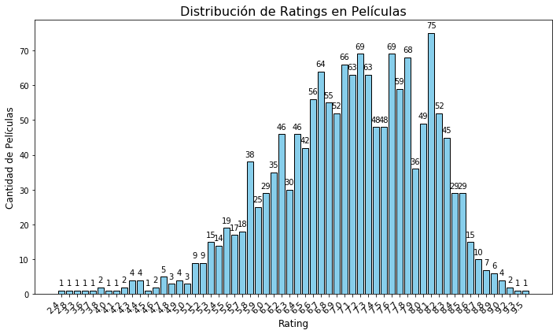

```python
import matplotlib.pyplot as plt

# Convertir el DataFrame de PySpark a Pandas para graficar
rating_count_pd = details_rating_grouped.toPandas()

# Crear un gráfico de barras mejorado
plt.figure(figsize=(10,6))  # tamaño de la figura
bars = plt.bar(rating_count_pd['rating'], rating_count_pd['count'], color='skyblue', edgecolor='black')

# Agregar etiquetas a las barras
for bar in bars:
    height = bar.get_height()
    plt.text(bar.get_x() + bar.get_width() / 2, height + 1, str(int(height)), ha='center', va='bottom', fontsize=10)

# Personalizacion
plt.title("Distribución de Ratings en Películas", fontsize=16)
plt.xlabel("Rating", fontsize=12)
plt.ylabel("Cantidad de Películas", fontsize=12)

# Aseguraramiento que las calificaciones estén alineadas horizontalmente
plt.xticks(rating_count_pd['rating'], rotation=45, ha='right', fontsize=11)  # Rotar las etiquetas para evitar superposición

# Mostrar el gráfico
plt.tight_layout()
plt.show()
```

#### 2.2 Analyzing the Dataset with Spark SQL

##### 2.2.1 Which user has written the most reviews? And who has written the fewest (if there are multiple, indicate how many)?

User who has written the most reviews:

```python
reviews.groupBy("user_id").agg({"movie_id":"count"}).orderBy("count(movie_id)", ascending=False).show(1)
```

```
+---------+---------------+
|  user_id|count(movie_id)|
+---------+---------------+
|ur2898520|           1303|
+---------+---------------+
only showing top 1 row
```

As we can see, there are quite a few users who share the minimum number of reviews. How many users share the minimum?

```python
review_counter_user = reviews.groupBy("user_id").agg({"movie_id": "count"}).orderBy("count(movie_id)", ascending=True)
```

```python
review_counter_user.show()
```

```
+----------+---------------+
|   user_id|count(movie_id)|
+----------+---------------+
| ur1153990|              1|
| ur1430482|              1|
| ur1103899|              1|
|ur48823143|              1|
|ur21059122|              1|
|ur39026579|              1|
|ur73297517|              1|
|ur47125783|              1|
| ur2916055|              1|
|ur81573403|              1|
|ur27508189|              1|
|ur69130034|              1|
|ur47738038|              1|
|ur80541192|              1|
|ur56009258|              1|
|ur44809077|              1|
|ur65947123|              1|
|ur66404918|              1|
| ur3181746|              1|
|ur51028935|              1|
+----------+---------------+
only showing top 20 rows
```

```python
review_count=reviews.groupBy("user_id").agg({"movie_id": "count"}).orderBy("count(movie_id)", ascending=True).withColumnRenamed("count(movie_id)", "review_count")
```

```python
review_count.where("review_count == " + str(review_count.agg({"review_count": "min"}).collect()[0][0])).count()
```

```
202194
```

##### 2.2.2 Which user has written the most reviews with spoilers?

Similarly to the previous query, now we want to find out which user has written the most reviews that contained content labeled as 'spoiler'.

```python
# We want to filter by those where the "is_spoiler" field is True.
reviews.where("is_spoiler == True").groupBy("user_id").agg({"movie_id": "count"}).orderBy("count(movie_id)", ascending=False).show(1)
```

```
+---------+---------------+
|  user_id|count(movie_id)|
+---------+---------------+
|ur4248714|           1019|
+---------+---------------+
only showing top 1 row
```

##### 2.2.3 Is there any inconsistency between the ratings in the details file and the reviews file?

To determine this, the average is calculated and compared with the one obtained from the details file. A new column is created in the dataset that shows the absolute difference, and the results are ordered by this column in descending order. This allows us to see which movies have the greatest inconsistencies between the two values.

Initially, we will select the `movieID` and its rating from the `movie_details` file. It is important to note that the rating is of type string, so it needs to be converted to double.

```python
# We have converted the rating type to double, as it is a string value and would not allow us to perform arithmetic operations.
from pyspark.sql.types import DoubleType
rating_movies_from_details_file=movie_details.select("movie_id","rating").withColumn("ratingD", movie_details["rating"].cast(DoubleType())).select("movie_id","ratingD")
```

```python
rating_reviews = reviews.withColumn("ratingD", reviews["rating"].cast(DoubleType())) \
    .select("movie_id", "ratingD") \
    .groupBy("movie_id") \
    .agg({"ratingD": "avg"}) \
    .orderBy("avg(ratingD)", ascending=True) \
    .withColumnRenamed("avg(ratingD)", "avg_rating_reviews")
```

```python
rating_movies_from_details_file.show(10)
```

```
+---------+-------+
| movie_id|ratingD|
+---------+-------+
|tt0144084|    7.6|
|tt0050976|    8.2|
|tt1345836|    8.4|
|tt0399201|    6.9|
|tt0103064|    8.5|
|tt0120912|    6.1|
|tt0119094|    7.3|
|tt0814255|    5.9|
|tt0454848|    7.6|
|tt0119654|    7.3|
+---------+-------+
only showing top 10 rows
```

Now, a join is performed between the two DataFrames, which allows us to compare the ratings from both DataFrames.

```python
joined = rating_movies_from_details_file.join(rating_reviews, rating_movies_from_details_file.movie_id == rating_reviews.movie_id, 'inner') \
    .select(rating_reviews.movie_id,
            rating_movies_from_details_file.ratingD.alias("rating_details"),
            rating_reviews.avg_rating_reviews.alias("rating_reviews"))
```

```python
joined.show()
```

```
+---------+--------------+------------------+
| movie_id|rating_details|    rating_reviews|
+---------+--------------+------------------+
|tt2488496|           8.0|2.5926928281461437|
|tt2527336|           7.5| 2.938775510204082|
|tt0118688|           3.7|3.1118210862619806|
|tt0185183|           2.4|3.1613394216133943|
|tt0105643|           2.8|3.2929577464788733|
|tt1392170|           7.2|3.4714285714285715|
|tt0938283|           4.2|3.6424657534246574|
|tt1099212|           5.2| 3.754874651810585|
|tt1502712|           4.3|          3.796875|
|tt1060277|           7.0|3.8971583220568338|
|tt1446714|           7.0| 4.025710419485792|
|tt0103923|           3.3|            4.0625|
|tt0388419|           5.3|  4.06282722513089|
|tt0312528|           3.8| 4.077562326869806|
|tt0449010|           5.1| 4.152472527472527|
|tt1389072|           5.8| 4.153846153846154|
|tt0120891|           4.8| 4.167728237791932|
|tt2955096|           5.5|               4.2|
|tt0816692|           8.6| 4.241519674355495|
|tt1606378|           5.3| 4.254620123203286|
+---------+--------------+------------------+
only showing top 20 rows
```

Finally, we will calculate the difference between the values in the `joined` DataFrame.

```python
from pyspark.sql.functions import abs

# Calculate the Relative Difference Between the Ratings
joined_relative_diff = joined.withColumn("relative_diff", joined.rating_details - joined.rating_reviews)

# Calculate the Absolute Difference
joined_absolute_diff = joined_relative_diff.withColumn("absolute_diff", abs(joined_relative_diff.relative_diff)) \
                                           .orderBy("absolute_diff", ascending=False)
```

```python
joined_absolute_diff.show()
```

```
+---------+--------------+------------------+------------------+------------------+
| movie_id|rating_details|    rating_reviews|     relative_diff|     absolute_diff|
+---------+--------------+------------------+------------------+------------------+
|tt2488496|           8.0|2.5926928281461437| 5.407307171853857| 5.407307171853857|
|tt2527336|           7.5| 2.938775510204082| 4.561224489795919| 4.561224489795919|
|tt0816692|           8.6| 4.241519674355495| 4.358480325644504| 4.358480325644504|
|tt1375666|           8.8| 4.832402234636872| 3.967597765363129| 3.967597765363129|
|tt0266697|           8.1|  4.27364185110664|  3.82635814889336|  3.82635814889336|
|tt1392170|           7.2|3.4714285714285715|3.7285714285714286|3.7285714285714286|
|tt0361748|           8.3| 4.701262272089761|3.5987377279102395|3.5987377279102395|
|tt0416449|           7.7| 4.287292817679558|3.4127071823204425|3.4127071823204425|
|tt2543164|           8.0|  4.59781121751026|3.4021887824897403|3.4021887824897403|
|tt1392190|           8.1| 4.703804347826087|3.3961956521739127|3.3961956521739127|
|tt1060277|           7.0|3.8971583220568338|3.1028416779431662|3.1028416779431662|
|tt1856101|           8.3| 5.230664857530529|3.0693351424694715|3.0693351424694715|
|tt1074638|           7.8| 4.772479564032698|3.0275204359673022|3.0275204359673022|
|tt0477348|           8.1| 5.122589531680441| 2.977410468319559| 2.977410468319559|
|tt0375679|           7.8| 4.822959889349931|2.9770401106500692|2.9770401106500692|
|tt1446714|           7.0| 4.025710419485792| 2.974289580514208| 2.974289580514208|
|tt0381061|           8.0| 5.075549450549451|2.9244505494505493|2.9244505494505493|
|tt5013056|           8.1| 5.266030013642565|2.8339699863574346|2.8339699863574346|
|tt0796366|           8.0| 5.270083102493075| 2.729916897506925| 2.729916897506925|
|tt0360717|           7.2| 4.497948016415869|2.7020519835841315|2.7020519835841315|
+---------+--------------+------------------+------------------+------------------+
only showing top 20 rows
```

##### 2.2.4 For action movies, what is the ratio of the number of spoilers to the total?

From now on, we will make more intensive use of Spark functions: https://spark.apache.org/docs/latest/api/sql/

The genre information is in the `details` file, while the spoiler information is in the `reviews` file. Therefore, we will need to perform a join between the two DataFrames again.

To calculate the ratio, first we need to filter the movies that belong to the "Action" genre and then perform the join with the `reviews` DataFrame to count the movies with spoilers.

```python
from pyspark.sql import functions as F
total_action_movies = movie_details.select("movie_id", F.explode("genre").alias("genre")) \
                                   .join(reviews, movie_details.movie_id == reviews.movie_id) \
                                   .where("genre == 'Action'")
```

```python
total_action_movies_count = total_action_movies.count()

movie_details.printSchema()
```

```
root
 |-- duration: string (nullable = true)
 |-- genre: array (nullable = true)
 |    |-- element: string (containsNull = true)
 |-- plot_summary: string (nullable = true)
 |-- plot_synopsis: string (nullable = true)
 |-- rating: string (nullable = true)
 |-- release_date: string (nullable = true)
 |-- movie_id: string (nullable = true)
```

Now we need to get the number of movies with spoilers.

```python
total_action_movies_count_spolier = total_action_movies.where("is_spoiler == True").count()
```

```python
relation = total_action_movies_count_spolier / total_action_movies_count
print("Ratio between the number of movies with spoilers and the total number of action movies:", relation)
```

```
Ratio between the number of movies with spoilers and the total number of action movies: 0.2826019704588474
```

##### 2.2.5 What is the average age of the movies? And what is the average absolute difference in the age of action movies and horror (Horror) movies?

We want to know the average age of the movies (in years), taking the release date as a reference against the current date. The result should be displayed in years.

As we encountered earlier with the ratings, it is necessary to change the format of the release date to a date format, since it is currently a string and Spark cannot operate with it. Therefore, we will use a new Spark function: to_date() on the release date field.

```python
movie_details_dates = movie_details.withColumn('converted_date', F.to_date(movie_details['release_date'], 'yyyy-MM-dd'))
```

```python
movies_age = movie_details_dates.select(
    F.col("*"),
    F.current_date().alias("current_date"),
    F.datediff(F.current_date(), F.col("converted_date")).alias("datediff")
).agg({"datediff": "avg"})
```

```python
movies_age.show()
```

```
+-----------------+
|    avg(datediff)|
+-----------------+
|8503.117948717949|
+-----------------+
```

The resulting dataframe is captured in an array using collect(). How many elements does the dataframe have?

```python
age = movies_age.collect()
len(age)
```

```
1
```

Now, it is necessary to take the numerical value of the average number of days of age and divide it by 365, which will give us the average in years.

```python
years_age=age[0][0]/365
```

[output not shown]

# Let's perform the grouping by genre of the average age of the movies.

```python
from pyspark.sql import functions as F

movie_details_with_diff = movie_details.withColumn('datediff', F.datediff(F.current_date(), F.col('release_date')))


movies_age_by_genre = movie_details_with_diff.select(F.explode(F.col('genre')).alias('genre'), 'datediff') \
    .groupBy('genre') \
    .agg(F.avg('datediff').alias('avg_datediff'))

movies_age_by_genre.show()
```

```
+---------+------------------+
|    genre|      avg_datediff|
+---------+------------------+
|    Crime| 8855.311258278145|
|  Romance| 9018.067510548522|
| Thriller| 8585.478448275862|
|Adventure| 7780.163972286374|
|    Drama| 9142.676286072772|
|      War|          14623.08|
|   Family| 9117.574193548387|
|  Fantasy| 7712.758426966292|
|  History|            9477.5|
|  Mystery| 8026.267080745341|
|  Musical| 9072.333333333334|
|Animation| 7213.511904761905|
|    Music| 8332.588235294117|
|Film-Noir|27431.666666666668|
|   Horror| 7991.370689655172|
|  Western|           13124.2|
|Biography| 7951.633663366337|
|   Comedy| 8656.709923664122|
|   Action| 7377.178082191781|
|    Sport| 8318.333333333334|
+---------+------------------+
only showing top 20 rows
```

Muestrad los resultados mediante un show().

```python
movies_age_by_genre.show()
```

```
+---------+------------------+
|    genre|      avg_datediff|
+---------+------------------+
|    Crime| 8847.311258278145|
|  Romance| 9010.067510548522|
| Thriller| 8577.478448275862|
|Adventure| 7772.163972286374|
|    Drama| 9134.676286072772|
|      War|          14615.08|
|   Family| 9109.574193548387|
|  Fantasy| 7704.758426966292|
|  History|            9469.5|
|  Mystery| 8018.267080745341|
|  Musical| 9064.333333333334|
|Animation| 7205.511904761905|
|    Music| 8324.588235294117|
|Film-Noir|27423.666666666668|
|   Horror| 7983.370689655172|
|  Western|           13116.2|
|Biography| 7943.633663366337|
|   Comedy| 8648.709923664122|
|   Action| 7369.178082191781|
|    Sport| 8310.333333333334|
+---------+------------------+
only showing top 20 rows
```

Now, it is necessary to select the genres in order to compare both values.

```python
horror_movie_age = movies_age_by_genre.where("genre == 'Horror'").collect()[0]['avg_datediff']
action_movie_age = movies_age_by_genre.where("genre == 'Action'").collect()[0]['avg_datediff']
```

```python
(horror_movie_age-action_movie_age)/365
```

```
1.6827194725024415
```

##### 2.2.6 Which user gives the best ratings (arithmetic mean)? And which user gives the worst ratings? NOTE: We will ignore users who have written fewer than 10 reviews, and if there is more than one, show them all.

```python
from pyspark.sql import functions as F

# 1. Filter users with at least 10 reviews
user_reviews = reviews.groupBy('user_id').agg(F.count('rating').alias('review_count'), F.avg('rating').alias('avg_rating'))
filtered_users = user_reviews.filter(F.col('review_count') >= 10)

# 2. Find the user with the best and worst average rating
best_user = filtered_users.orderBy(F.desc('avg_rating')).first()  # User with the best rating
worst_user = filtered_users.orderBy(F.asc('avg_rating')).first()  # User with the worst rating

# 3. Display results
print("Best user: {} with an average rating of {:.2f}".format(best_user['user_id'], best_user['avg_rating']))
print("Worst user: {} with an average rating of {:.2f}".format(worst_user['user_id'], worst_user['avg_rating']))
```

```
Best user: ur23748553 with an average rating of 10.00
Worst user: ur58549266 with an average rating of 1.12
```

##### 2.2.7 Average of movie ratings by genre.

```python
# 1. Rename the 'rating' column in the reviews DataFrame
reviews_renamed = reviews.withColumnRenamed("rating", "review_rating")

# 2. Join the 'movie_details' and 'reviews' tables by 'movie_id'
movies_with_ratings = movie_details.join(reviews_renamed, on="movie_id", how="left")

# 3. Explode the 'genre' column (and not 'genres')
movies_with_ratings_exploded = movies_with_ratings.withColumn("genre", F.explode("genre"))

# 4. Group by 'genre' and calculate the average ratings (review_rating)
rating_by_genre = movies_with_ratings_exploded.groupBy('genre').agg(F.avg('review_rating').alias('avg_rating'))

# 5. Display the results
rating_by_genre.show()
```

```
+---------+------------------+
|    genre|        avg_rating|
+---------+------------------+
|    Crime| 7.304695905899517|
|  Romance| 7.104259088446728|
| Thriller| 6.750170655632686|
|Adventure| 6.686021367589819|
|    Drama| 7.305266795687033|
|      War| 7.624071177160736|
|   Family| 6.968249955762279|
|  Fantasy| 6.691574359905575|
|  History| 7.370897291900661|
|  Mystery| 6.828808293391204|
|  Musical| 7.362268938021022|
|Animation| 7.828326502989059|
|    Music| 7.399725902238465|
|Film-Noir| 8.616973757677275|
|   Horror| 6.434550273597811|
|  Western|7.7122969837587005|
|Biography| 7.733681698734407|
|   Comedy| 6.956004353965639|
|   Action| 6.479574448004111|
|    Sport| 7.434756679389313|
+---------+------------------+
only showing top 20 rows
```

##### 2.2.8 What are the 10 years with the highest number of 'released' movies?

```python
from pyspark.sql import functions as F

# 1. Extract the year from the 'release_date' column
movies_with_year = movie_details.withColumn("release_year", F.year("release_date"))

# 2. Group by 'release_year' and count the number of movies per year
movies_by_year = movies_with_year.groupBy("release_year").count()

# 3. Sort the results by the number of movies in descending order
top_10_years = movies_by_year.orderBy(F.desc("count")).limit(10)

# 4. Show the results
top_10_years.show()
```

```
+------------+-----+
|release_year|count|
+------------+-----+
|        2017|   69|
|        2006|   61|
|        2015|   57|
|        2007|   55|
|        2003|   54|
|        1994|   54|
|        2004|   54|
|        2002|   54|
|        2009|   53|
|        2010|   53|
+------------+-----+
```